# Adaptive Rejection Sampling vs Standard Rejection Sampling

Nikolai German

2025-07-07

# 1 Introduction

We compare two rejection sampling methods for the **standard normal distribution** $N(0,1)$ on the domain $[-4, 4]$:

1. **Standard Rejection Sampling**: Uses uniform proposal on $[-4, 4]$ with fixed envelope
2. **Adaptive Rejection Sampling (ARS)**: Builds and refines a piecewise linear envelope in log-space

The **ARS algorithm** builds a piecewise linear upper envelope in log-space: 1. Initialize support points and compute tangent lines: $\ell_i(x) = \log f(x_i) + f'(x_i)(x - x_i)$ 2. Construct envelope: $\log \hat{s}(x) = \min_i \ell_i(x)$ 3. Sample from $\hat{s}(x)$ using segment-wise inverse CDF 4. Accept/reject against true density; add rejection points for adaptation

# 2 Implementation

First, we define the mathematical functions needed for working with the standard normal distribution:

```r
# Log-density and derivative for standard normal
log_normal_density <- function(x) {
  -0.5 * log(2 * pi) - 0.5 * x^2
}

log_normal_derivative <- function(x) {
  -x
}

normal_density <- function(x) {
  exp(log_normal_density(x))
}
```

## 2.1 Standard Rejection Sampling

The standard rejection method uses a simple uniform proposal distribution over the domain $[-4, 4]$. The envelope is fixed and equal to the maximum density value $M = \frac{1}{\sqrt{2\pi}}$ times the uniform density.

```r
# Standard rejection sampling with uniform proposal
standard_rejection_sampler <- function(n, domain = c(-4, 4)) {
  # Maximum of normal density on [-4, 4] is at x=0
  M <- 1 / sqrt(2 * pi)  # ≈ 0.399

  samples <- numeric(n)
  n_accepted <- 0
  n_total <- 0

  while (n_accepted < n) {
    x_prop <- runif(1, domain[1], domain[2])
    u <- runif(1)

    n_total <- n_total + 1

    if (u <= normal_density(x_prop) / M) {
      n_accepted <- n_accepted + 1
      samples[n_accepted] <- x_prop
    }
  }

  attr(samples, "acceptance_rate") <- n_accepted / n_total
  samples
}
```

## 2.2 ARS: Building the Piecewise Linear Envelope

The core of ARS is constructing a piecewise linear upper envelope in log-space. Given support points $x_1, \ldots, x_k$, we compute tangent lines $\ell_i(x) = \log f(x_i) + f'(x_i)(x - x_i)$ and find their intersections to create envelope segments. The envelope at any point is $\log \hat{s}(x) = \min_i \ell_i(x)$.

```r
# Function to build piecewise linear envelope structure
build_ars_envelope <- function(support_points, domain = c(-4, 4)) {
  # Sort support points
  support_points <- sort(unique(support_points))
  k <- length(support_points)

  # Compute log-densities and derivatives at support points
  log_f <- log_normal_density(support_points)
  df <- log_normal_derivative(support_points)

  # Find intersection points of adjacent tangent lines
  # Solve: log_f[i] + df[i]*(x - support_points[i]) = log_f[i+1] + df[i+1]*(x - support_points[i+1])
  intersections <- numeric(k - 1)
  for (i in 1:(k-1)) {
    intersections[i] <- (log_f[i+1] - log_f[i] - df[i+1]*support_points[i+1] + df[i]*support_points[i]) /
                       (df[i] - df[i+1])
  }

  # Define envelope segments: [domain[1], intersections[1], ..., intersections[k-1], domain[2]]
  boundaries <- c(domain[1], intersections, domain[2])

  # Return envelope structure (without probabilities)
  list(
    support_points = support_points,
    boundaries = boundaries,
    log_f = log_f,
    df = df
  )
}
```

For a given envelope, we want to be able, to sample from it. To achieve that, `calculate_segment_probabilities` is a helper, which returns the probabilities for each segment of a given envelope.

```r
# Function to calculate segment probabilities
calculate_segment_probabilities <- function(envelope_info) {
  k <- length(envelope_info$support_points)
  boundaries <- envelope_info$boundaries
  log_f <- envelope_info$log_f
  df <- envelope_info$df

  # Compute normalization constants for each segment
  # Each segment has form: exp(a*x + b) where a = df[i], b = log_f[i] - df[i]*support_points[i]
  segment_probs <- numeric(k)
  for (i in 1:k) {
    a <- df[i]  # slope of tangent line
    b <- log_f[i] - df[i] * envelope_info$support_points[i]  # intercept

    if (abs(a) < 1e-10) {  # Nearly constant segment
      segment_probs[i] <- exp(b) * (boundaries[i+1] - boundaries[i])
    } else {  # Exponential segment
      segment_probs[i] <- exp(b) * (exp(a * boundaries[i+1]) - exp(a * boundaries[i])) / a
    }
  }

  # Return normalized probabilities
  segment_probs / sum(segment_probs)
}
```

## 2.3 ARS: Sampling from the Piecewise Envelope

Once the envelope is constructed, we sample from it using a two-step process: (1) choose a segment based on segment probabilities, (2) sample from the chosen exponential/uniform segment using inverse CDF. Each segment has the form $\exp(ax + b)$ on its interval.

```r
# Function to sample from the piecewise envelope
sample_from_envelope <- function(n_samples, envelope_info, segment_probs) {
  samples <- numeric(n_samples)

  for (i in 1:n_samples) {
    # Step 1: Choose segment based on probabilities
    segment <- sample(1:length(segment_probs), 1, prob = segment_probs)

    # Step 2: Sample from chosen segment
    # Get segment parameters
    a <- envelope_info$df[segment]  # slope
    b <- envelope_info$log_f[segment] - envelope_info$df[segment] * envelope_info$support_points[segment]  # intercept
    x_min <- envelope_info$boundaries[segment]
    x_max <- envelope_info$boundaries[segment + 1]

    if (abs(a) < 1e-10) {
      # Nearly constant segment: uniform sampling
      samples[i] <- runif(1, x_min, x_max)
    } else {
      # Exponential segment: inverse CDF sampling
      # We want to sample from exp(ax + b) on [x_min, x_max]
      # CDF: F(x) = [exp(ax + b) - exp(a*x_min + b)] / [exp(a*x_max + b) - exp(a*x_min + b)]
      u <- runif(1)
      if (a > 0) {
        samples[i] <- log(u * (exp(a * x_max) - exp(a * x_min)) + exp(a * x_min)) / a
      } else {
        samples[i] <- log((1 - u) * (exp(a * x_min) - exp(a * x_max)) + exp(a * x_max)) / a
      }
    }
  }

  samples
}
```

## 2.4 Complete ARS Implementation

Now we combine envelope building and sampling into the full adaptive algorithm. The key insight is that rejections provide information about where the envelope is too loose, so we add rejection points as new support points to improve the envelope.

```r
# Complete ARS implementation
ars_sampler <- function(n, domain = c(-4, 4), eps = 0.1) {
  # Initialize support points: domain edges + midpoint
  midpoint <- mean(domain)
  support_points <- c(domain[1] + eps, midpoint, domain[2] - eps)

  samples <- numeric(n)
  n_accepted <- 0
  n_total <- 0
  adaptation_history <- list()

  # Store initial support points
  initial_support_points <- support_points

  while (n_accepted < n) {
    # Build envelope structure
    envelope_info <- build_ars_envelope(support_points, domain)

    # Calculate segment probabilities
    segment_probs <- calculate_segment_probabilities(envelope_info)

    # Sample from envelope
    x_prop <- sample_from_envelope(1, envelope_info, segment_probs)

    # Accept/reject against true density
    # Compute envelope value at proposed point
    # Find which segment contains x_prop
    segment <- which(x_prop >= envelope_info$boundaries[-length(envelope_info$boundaries)] &
                    x_prop < envelope_info$boundaries[-1])[1]
    if (is.na(segment)) segment <- length(envelope_info$support_points)  # Handle boundary case

    envelope_val <- envelope_info$log_f[segment] + envelope_info$df[segment] * (x_prop - envelope_info$support_points[segment])
    log_target <- log_normal_density(x_prop)

    n_total <- n_total + 1

    if (log(runif(1)) <= log_target - envelope_val) {
      # Accept the sample
      n_accepted <- n_accepted + 1
      samples[n_accepted] <- x_prop
    } else {
      # Reject and adapt: add rejection point to support set
      support_points <- c(support_points, x_prop)
      adaptation_history[[length(adaptation_history) + 1]] <- x_prop
    }
  }

  attr(samples, "acceptance_rate") <- n_accepted / n_total
  attr(samples, "adaptations") <- length(adaptation_history)
  attr(samples, "initial_support_points") <- initial_support_points
  attr(samples, "final_support_points") <- sort(unique(support_points))
  samples
}
```

# 3 Envelope Comparison: Initial vs After Adaptation

Let’s compare the envelope quality at the beginning versus after sampling 100 points:

```r
# Function to visualize envelope
plot_envelope <- function(n_points, same.seed = TRUE) {
  if(same.seed) {
    set.seed(42)
  }
  ars_samples <- ars_sampler(n_points)
  acceptance_rate <- attr(ars_samples, "acceptance_rate")
  support_points <- attr(ars_samples, "final_support_points")
  envelope_info <- build_ars_envelope(support_points)

  title = ifelse(n_points == 0,
                 "Initial Envelope",
                 sprintf("After %d samples", n_points))

  x_grid <- seq(-4, 4, length.out = 300)
  true_log_density <- log_normal_density(x_grid)
  envelope <- numeric(length(x_grid))

  for (i in seq_along(x_grid)) {
    x <- x_grid[i]
    tangent_values <- envelope_info$log_f + envelope_info$df * (x - envelope_info$support_points)
    envelope[i] <- min(tangent_values)
  }

  tibble(x = x_grid,
         envelope = envelope,
         true_log_density = true_log_density) %>%
    ggplot(aes(x)) +
    stat_function(fun = log_normal_density, color = "#f8766d", lwd = 1.2) +
    geom_line(aes(y = envelope), color = "#619cff", lwd = 1, linetype = "dashed") +
    geom_point(data = tibble(
      x = support_points,
      y = log_normal_density(support_points)
      ), aes(x, y), color = "#619", size = 1.8, alpha = .7) +
    scale_x_continuous(limits = c(-4, 4)) +
    scale_y_continuous(limits = c(-10, 0)) +
    theme_light() +
    labs(x = "x", y = "Log-density",
         title = title,
         subtitle = ifelse(is.na(acceptance_rate),
                           sprintf("%d support points", length(support_points)),
                           sprintf("%d support points \n%.1f%% acceptance rate", length(support_points), 100*acceptance_rate)))
}
```

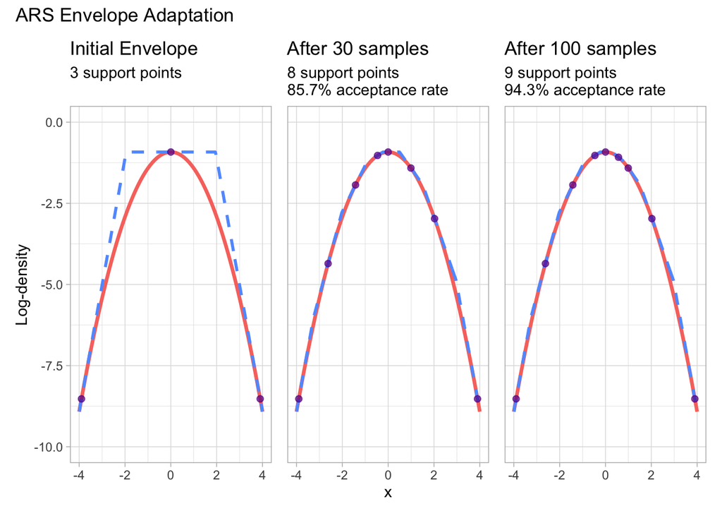

```r
# Generate ARS samples to get initial and final support points
plots <- lapply(c(0, 30, 100), plot_envelope)

(p_envelope_comparison <- (plots[[1]] | plots[[2]] | plots[[3]]) +
  plot_annotation(
    title = "ARS Envelope Adaptation"
  ) + plot_layout(axes = "collect"))
```

# 4 Acceptance Rate Comparison

Now let’s compare the acceptance rates of both methods across different sample sizes:

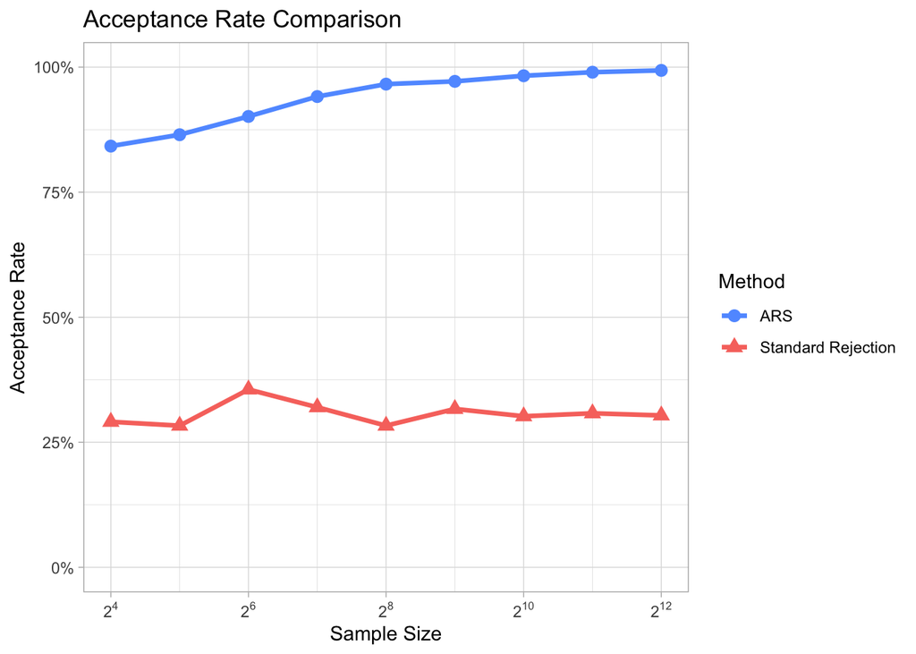

```r
# Compare acceptance rates across sample sizes
compare_acceptance_rates <- function(sample_sizes = 2^seq(4, 12)) {
  set.seed(42)

  results <- tibble()

  for (n in sample_sizes) {
    # Standard rejection sampling
    std_samples <- standard_rejection_sampler(n)
    std_acceptance <- attr(std_samples, "acceptance_rate")

    # ARS
    ars_samples <- ars_sampler(n)
    ars_acceptance <- attr(ars_samples, "acceptance_rate")
    ars_adaptations <- attr(ars_samples, "adaptations")

    results <- rbind(results, tibble(
      n_samples = n,
      method = c("Standard Rejection", "ARS"),
      acceptance_rate = c(std_acceptance, ars_acceptance),
      adaptations = c(NA, ars_adaptations)
    ))
  }

  results
}

acceptance_comparison <- compare_acceptance_rates()

# Plot acceptance rates
(p_acceptance_comparison <- acceptance_comparison %>%
  ggplot(aes(log2(n_samples), acceptance_rate, color = method, shape = method)) +
  geom_line(size = 1.2) +
  geom_point(size = 3) +
  scale_color_manual(values = c("#619cff", "#f8766d")) +
  scale_shape_manual(values = c(16, 17)) +
  scale_y_continuous(labels = scales::percent_format(), limits = c(0, 1)) +
  scale_x_continuous(labels = scales::label_math(expr = 2^.x)) +
  theme_light() +
  labs(x = "Sample Size",
       y = "Acceptance Rate",
       title = "Acceptance Rate Comparison",
       color = "Method", shape = "Method"))
```

# 5 Distribution Quality Validation

Finally, let’s verify that both methods produce correct samples with larger sample sizes:

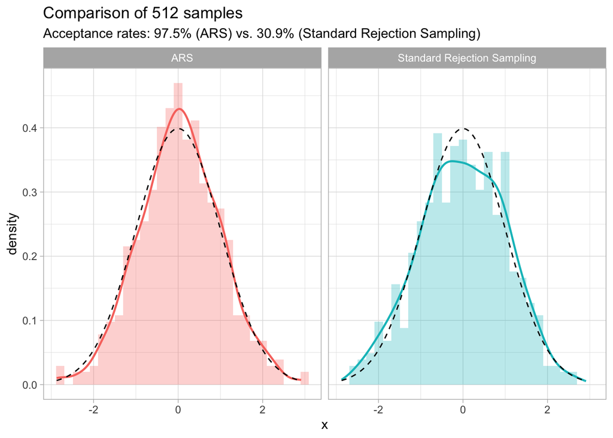

```r
# Generate final comparison samples
set.seed(123)
n_final <- 512

ars_final <- ars_sampler(n_final)
std_final <- standard_rejection_sampler(n_final)

(p_distr_comparison <- tibble("ARS" = ars_final, "Standard Rejection Sampling" = std_final) %>%
  pivot_longer(everything(), values_to = "value", names_to = "method") %>%
  ggplot(aes(value)) +
  geom_density(aes(color = method), lwd = .8) +
  geom_histogram(aes(y = ..density.., fill = method), alpha = .3, ) +
  stat_function(fun = dnorm, lty = "dashed") +
  guides(color = "none", fill = "none") +
  facet_wrap(~method) +
  theme_light() +
    labs(title = sprintf("Comparison of %d samples", n_final),
         subtitle = sprintf("Acceptance rates: %.1f%% (ARS) vs. %.1f%% (Standard Rejection Sampling)", 100*attr(ars_final, "acceptance_rate"), 100*attr(std_final, "acceptance_rate")),
         x = "x"))
```

# 6 Summary

The comparison between ARS and standard rejection sampling reveals several key insights:

**Adaptive Learning:** - ARS automatically improves by adding support points where rejections occur - Each adaptation makes the envelope tighter around the target density - The method becomes progressively more efficient during sampling

**Practical Implications:** - ARS requires more complex implementation but pays off with superior efficiency - Standard rejection is simple but wasteful for complex domains - The adaptive nature makes ARS robust across different target distributions

**Key Takeaway**: While standard rejection sampling has the advantage of simplicity, ARS demonstrates the power of adaptive algorithms. By learning from rejections, ARS transforms computational “waste” into useful information, leading to dramatically improved sampling efficiency. This principle extends beyond normal distributions to any log-concave target, making ARS a powerful general-purpose sampling tool.